# Cyclistic Case Study Analysis Report

Noah Bogatinoff

10/27/2021

#### [My Portfolio](https://noahbogatinoff.github.io/)

### Cyclistic: The Company and Background

Cyclistic is a bike share company from Chicago that features over 5,800 bicycles along with over 600 docking stations. The company launched in 2016 and has grown its fleet to where they are today.

Ride-share bikes can be unlocked from any location and returned to any other station in the system at any point in time. By offering reclining bikes, hand tricycles, and cargo bikes, Cyclistic wants to make the bike-share industry more inclusive to riders who can’t use a standard two-wheeled bike or those with disabilities.

Cyclistic offers flexible pricing plans, **including single-ride passes, full-day passes, and annual memberships.** Customers who purchase annual memberships are referred to as Cyclistic members, while those who purchase other pass options are considered causal riders.

### The Problem

Until now, Cyclistic’s marketing strategy relied on building general awareness and appealing to broad consumer segments. However, the company believes the future success depends on **maximizing the number of annual memberships.**

**It is essential to understand how casual riders and annual members use Cyclistic bikes differently.** From these insights, your team will design a new marketing strategy to convert casual riders into annual members. These insights will affect how the company implements a new marketing program to convert casual riders into members.

### The Data

For the purpose of the case study, the data is made available by Motivate International Inc. and is presumed to be reliable, original, and free from bias.

Data privacy issues prevent disclosure of riders demographic information, aside from gender. Data collection procedures were changed as of early 2020, this will be accounted for in the data cleaning process.

```r
colnames(q1_2020)
```

```
##  [1] "ride_id"            "rideable_type"      "started_at"
##  [4] "ended_at"           "start_station_name" "start_station_id"
##  [7] "end_station_name"   "end_station_id"     "start_lat"
## [10] "start_lng"          "end_lat"            "end_lng"
## [13] "member_casual"
```

### Cleaning The Data

A few issues arise with the data formatting. At the moment, there are several files, with inconsistent column naming procedures. To begin, we can rename the column headers within each file to represent the most recent naming procedure **(Q1 2020)**.

```r
## rename columns to match q1_2020 (most recent design)

(q1_2019 <- rename(q1_2019,ride_id = trip_id,
                   rideable_type = bikeid,
                   started_at = start_time,
                   ended_at = end_time,
                   start_station_name = from_station_name,
                   start_station_id = from_station_id,
                   end_station_name = to_station_name,
                   end_station_id = to_station_id,
                   member_casual = usertype))
(q2_2019 <- rename(q2_2019,
                   ride_id = "01 - Rental Details Rental ID",
                   rideable_type = "01 - Rental Details Bike ID",
                   started_at = "01 - Rental Details Local Start Time",
                   ended_at = "01 - Rental Details Local End Time",
                   start_station_name = "03 - Rental Start Station Name",
                   start_station_id = "03 - Rental Start Station ID",
                   end_station_name = "02 - Rental End Station Name",
                   end_station_id = "02 - Rental End Station ID",
                   member_casual = "User Type"))
(q3_2019 <- rename(q3_2019,
                   ride_id = trip_id,
                   rideable_type = bikeid,
                   started_at = start_time,
                   ended_at = end_time,
                   start_station_name = from_station_name,
                   start_station_id = from_station_id,
                   end_station_name = to_station_name,
                   end_station_id = to_station_id,
                   member_casual = usertype))
(q4_2019 <- rename(q4_2019,
                   ride_id = trip_id,
                   rideable_type = bikeid,
                   started_at = start_time,
                   ended_at = end_time,
                   start_station_name = from_station_name,
                   start_station_id = from_station_id,
                   end_station_name = to_station_name,
                   end_station_id = to_station_id,
                   member_casual = usertype))
```

Once these columns are renamed, we can see if the data is ready to be combined into 1 data frame. However, after looking at the structure of each new column, I noticed that **ride_id** and **rideable_type** in the above 4 columns appear as double data types. This needs to be converted to a character data type so these values can stack.

```r
q4_2019 <- mutate(q4_2019, ride_id = as.character(ride_id)
                  ,rideable_type = as.character(rideable_type))
q3_2019 <- mutate(q3_2019, ride_id = as.character(ride_id)
                  ,rideable_type = as.character(rideable_type))
q2_2019 <- mutate(q2_2019, ride_id = as.character(ride_id)
                  ,rideable_type = as.character(rideable_type))
q1_2019 <- mutate(q1_2019, ride_id = as.character(ride_id)
                  ,rideable_type = as.character(rideable_type))
```

At this point, we are ready to combine the several files into 1 larger data frame, titled **all_trips**.

```r
## Combine the quarterly files into a single file
all_trips <- bind_rows(q1_2019,q2_2019,q3_2019,q4_2019,q1_2020)
```

These files are now combined into a data frame making the future analysis much easier. De to the new data collecting procedures, we see that there are certain columns in previous years data that are not used in the new system. We can remove these columns from the new data frame.

```r
## Remove fields that were dropped in new data collecting format(lat,lon,birthyear, and gender)
all_trips <- all_trips %>%
  select(-c(start_lat,start_lng,end_lat,end_lng,birthyear,gender,"01 - Rental Details Duration In Seconds Uncapped","05 - Member Details Member Birthday Year","Member Gender","tripduration"))
```

Now we have a single data frame with consistent column names. Inspecting the new table that was created will give us a better idea of what we need to clean or adjust.

```r
colnames(all_trips)
```

```
## [1] "ride_id"            "started_at"         "ended_at"
## [4] "rideable_type"      "start_station_id"   "start_station_name"
## [7] "end_station_id"     "end_station_name"   "member_casual"
```

```r
summary(all_trips)
```

```
##    ride_id            started_at                     ended_at
##  Length:4244891     Min.   :2019-01-01 00:04:37   Min.   :2019-01-01 00:11:07
##  Class :character   1st Qu.:2019-06-05 11:55:20   1st Qu.:2019-06-05 12:16:37
##  Mode  :character   Median :2019-08-05 11:56:21   Median :2019-08-05 12:28:06
##                     Mean   :2019-08-09 22:35:19   Mean   :2019-08-09 22:59:17
##                     3rd Qu.:2019-10-06 08:15:10   3rd Qu.:2019-10-06 08:48:37
##                     Max.   :2020-03-31 23:51:34   Max.   :2020-05-19 20:10:34
##
##  rideable_type      start_station_id start_station_name end_station_id
##  Length:4244891     Min.   :  1.0    Length:4244891     Min.   :  1.0
##  Class :character   1st Qu.: 77.0    Class :character   1st Qu.: 77.0
##  Mode  :character   Median :174.0    Mode  :character   Median :174.0
##                     Mean   :202.5                       Mean   :203.3
##                     3rd Qu.:289.0                       3rd Qu.:291.0
##                     Max.   :675.0                       Max.   :675.0
##                                                         NA's   :1
##  end_station_name   member_casual
##  Length:4244891     Length:4244891
##  Class :character   Class :character
##  Mode  :character   Mode  :character
##
##
##
##
```

Using these functions, we have a basic insight into the new data frame. This helped me realize that the member_casual column has two extra names, including “Subscriber” and “Customer”. In the new data collection procedures, these names were changed to “Member” and “Casual” respectively.

```r
## Change member_casual column to only include "member" and "casual"
table(all_trips$member_casual) #shows us how many observations are under each usertype initially
```

```
##
##     casual   Customer     member Subscriber
##      48480     880637     378407    2937367
```

```r
all_trips <- all_trips %>%
  mutate(member_casual= recode(member_casual,
                                "Subscriber" = "member",
                                "Customer" = "casual"))
table(all_trips$member_casual) ## "check to make sure if proper values were assigned
```

```
##
##  casual  member
##  929117 3315774
```

```r
## "Subscriber" and"Customer" should be removed
```

The “Subscriber” and “Customer” labels should be replaced with “Member” and “Casual”.

As a part of the initial analysis, it is important to view the differences in the data depending on the day of the week. Due to this, we need to create columns that list date, month, day, and year of each ride.

Additionally, it would be beneficial to see the difference in the length of a ride between member and casual riders. We will also add a **ride_length** calculation to the data frame.

```r
## Create columns to aggregate date, month, day, and year of each ride
all_trips$date <- as.Date(all_trips$started_at)
all_trips$month <- format(as.Date(all_trips$date), "%m")
all_trips$day <- format(as.Date(all_trips$date), "%d")
all_trips$year <- format(as.Date(all_trips$date), "%Y")
all_trips$day_of_week <- format(as.Date(all_trips$date), "%A")
all_trips$ride_length <- difftime(all_trips$ended_at, all_trips$started_at)
```

After inspecting the new structure of the data frame, we find that we need to convert the **ride_length** variable to a numeric value for further calculations.

```r
## Convert ride_length to numeric for future calculations
all_trips$ride_length <- as.numeric(as.character(all_trips$ride_length))
is.numeric(all_trips$ride_length) #check assigned data type
```

```
## [1] TRUE
```

```r
summary(all_trips$ride_length)
```

```
##     Min.  1st Qu.   Median     Mean  3rd Qu.     Max.
##    -3382      401      691     1438     1249 10632022
```

**ride_length** is now a numeric value that will help in our analysis. However, we can see the minimum value is negative. This is due to Cyclistic taking bikes out of circulation for quality control reasons. These values need to be removed as to not affect the analysis. To do so, we will create a new data frame to not lose the original data.

```r
## Remove negative ride_length values
all_trips_v2 <- all_trips[!(all_trips$start_station_name == "HQ QR" | all_trips$ride_length<0),]
```

With the data now cleaned, we can move into our analysis.

### Cyclistic Analysis

The first thing we can do is take an initial look at the difference between casual and member riders.

```r
## compare member vs. casual riders
aggregate(all_trips_v2$ride_length ~ all_trips_v2$member_casual, FUN = mean)
```

```
##   all_trips_v2$member_casual all_trips_v2$ride_length
## 1                     casual                3556.8495
## 2                     member                 848.3654
```

```r
aggregate(all_trips_v2$ride_length ~ all_trips_v2$member_casual, FUN = median)
```

```
##   all_trips_v2$member_casual all_trips_v2$ride_length
## 1                     casual                     1542
## 2                     member                      579
```

```r
aggregate(all_trips_v2$ride_length ~ all_trips_v2$member_casual, FUN = max)
```

```
##   all_trips_v2$member_casual all_trips_v2$ride_length
## 1                     casual                 10632022
## 2                     member                  9056634
```

```r
aggregate(all_trips_v2$ride_length ~ all_trips_v2$member_casual, FUN = min)
```

```
##   all_trips_v2$member_casual all_trips_v2$ride_length
## 1                     casual                        2
## 2                     member                        1
```

This initial look at the data shows us that casual riders tend to rent the bikes for a **longer** period of time. We can take a further look and compare the difference in average **ride_length** depending on the day of the week. This will give us a better idea of when each group tends to rent their bikes.

```r
## arrange by day_of_week
all_trips_v2$day_of_week <- ordered(all_trips_v2$day_of_week, levels=c("Sunday", "Monday", "Tuesday", "Wednesday", "Thursday", "Friday", "Saturday"))
##compare average ride_length by day for member and casual riders
aggregate(all_trips_v2$ride_length ~ all_trips_v2$member_casual + all_trips_v2$day_of_week, FUN = mean)
```

```
##    all_trips_v2$member_casual all_trips_v2$day_of_week all_trips_v2$ride_length
## 1                      casual                   Sunday                3559.2956
## 2                      member                   Sunday                 927.2716
## 3                      casual                   Monday                3359.6077
## 4                      member                   Monday                 845.8799
## 5                      casual                  Tuesday                3562.1547
## 6                      member                  Tuesday                 829.8321
## 7                      casual                Wednesday                3702.9008
## 8                      member                Wednesday                 813.8020
## 9                      casual                 Thursday                3803.1191
## 10                     member                 Thursday                 811.8656
## 11                     casual                   Friday                3768.9980
## 12                     member                   Friday                 825.5616
## 13                     casual                 Saturday                3339.9183
## 14                     member                 Saturday                 973.5914
```

We can arrange the data by **member_casual** first, and then by **weekday** to make the data a bit easier to read.

```r
## analyze rider data by weekday and rider type
all_trips_v2 %>%
  mutate(weekday = wday(started_at, label = TRUE)) %>%
  group_by(member_casual, weekday) %>%
  summarize(number_of_rides = n(), average_duration = mean(ride_length)) %>%
  arrange(member_casual, weekday)
```

```
## # A tibble: 14 × 4
## # Groups:   member_casual [2]
##    member_casual weekday number_of_rides average_duration
##    <chr>         <ord>             <int>            <dbl>
##  1 casual        Sun              185059            3559.
##  2 casual        Mon              105188            3360.
##  3 casual        Tue               93238            3562.
##  4 casual        Wed               94946            3703.
##  5 casual        Thu              105599            3803.
##  6 casual        Fri              125779            3769.
##  7 casual        Sat              215536            3340.
##  8 member        Sun              292198             927.
##  9 member        Mon              520703             846.
## 10 member        Tue              566722             830.
## 11 member        Wed              558254             814.
## 12 member        Thu              548160             812.
## 13 member        Fri              512462             826.
## 14 member        Sat              317267             974.
```

We see again that the average length per ride is much longer for the casual group. However, we do see some new interesting insights.

Among the **member** group, a majority of the rentals occur between Monday and Friday.

Now what do these numbers actually look like.

### Total Rides (Casual vs. Member)

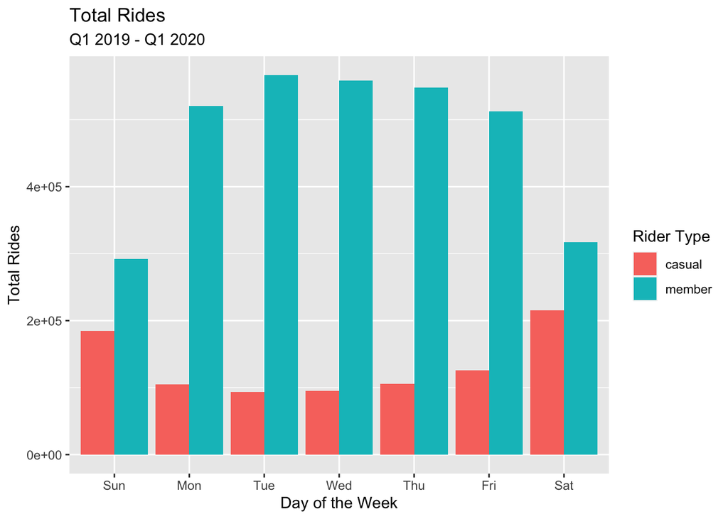

Among the **member** group, a majority of the rentals occur between Monday and Friday. Likely, this could be due to a reliance on Cyclistics bikes to get them to and from work. These riders with reliance and regular use are more likely to purchase annual memberships from Cyclistic. Using these bikes almost every day makes the annual membership the most cost efficient option for these individuals.

### Average Ride Length (Casual vs. Member)

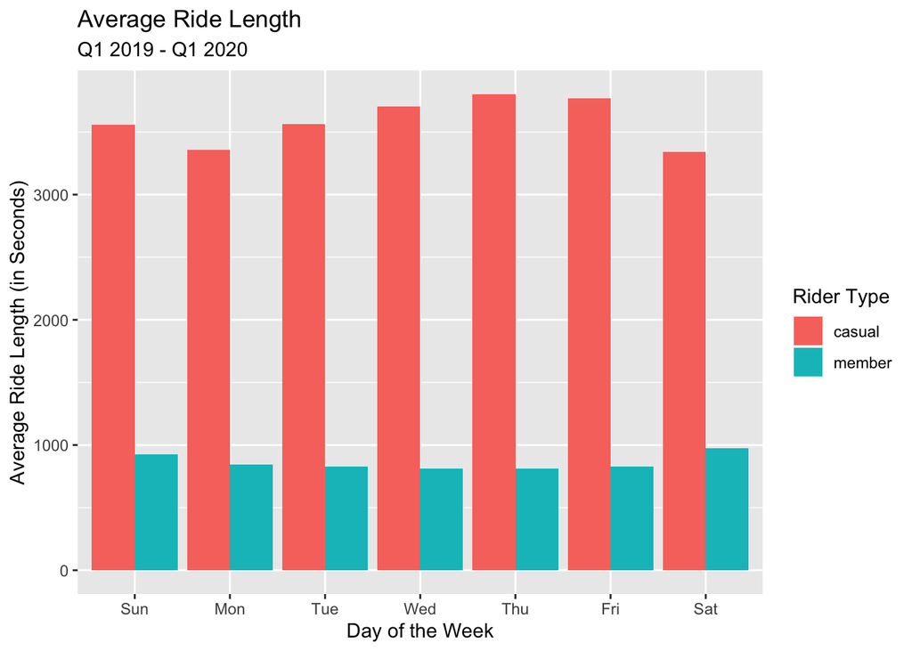

When comparing **member** vs. **casual** users, we can see that, on average, casual riders rent Cyclistics’ bikes for a much longer period of time. Casual riders typically rent their bike for 60 minutes, while member riders typically only spend about 15 minutes with their rental.

Lastly, Looking at stations to inspect for high foot traffic might be able to give us some more information.

```r
head(count(all_trips_v2, start_station_name,member_casual,sort=TRUE),n=10)
```

```
## # A tibble: 10 × 3
##    start_station_name           member_casual     n
##    <chr>                        <chr>         <int>
##  1 Canal St & Adams St          member        58161
##  2 Streeter Dr & Grand Ave      casual        54634
##  3 Clinton St & Madison St      member        52536
##  4 Clinton St & Washington Blvd member        51201
##  5 Lake Shore Dr & Monroe St    casual        40828
##  6 Columbus Dr & Randolph St    member        35469
##  7 Kingsbury St & Kinzie St     member        35145
##  8 Franklin St & Monroe St      member        34412
##  9 Daley Center Plaza           member        33517
## 10 Canal St & Madison St        member        30634
```

```r
head(count(all_trips_v2, end_station_name,member_casual,sort=TRUE),n=10)
```

```
## # A tibble: 10 × 3
##    end_station_name             member_casual     n
##    <chr>                        <chr>         <int>
##  1 Streeter Dr & Grand Ave      casual        69441
##  2 Canal St & Adams St          member        55488
##  3 Clinton St & Washington Blvd member        55203
##  4 Clinton St & Madison St      member        50951
##  5 Kingsbury St & Kinzie St     member        34707
##  6 Daley Center Plaza           member        33888
##  7 Lake Shore Dr & Monroe St    casual        31942
##  8 Michigan Ave & Washington St member        31606
##  9 Franklin St & Monroe St      member        30376
## 10 Canal St & Madison St        member        29856
```

```r
head(count(filter(all_trips_v2, start_station_name == end_station_name), start_station_name,member_casual,sort=TRUE),n=10)
```

```
## # A tibble: 10 × 3
##    start_station_name         member_casual     n
##    <chr>                      <chr>         <int>
##  1 Streeter Dr & Grand Ave    casual         8783
##  2 Lake Shore Dr & Monroe St  casual         8465
##  3 Michigan Ave & Oak St      casual         5134
##  4 Millennium Park            casual         3029
##  5 Montrose Harbor            casual         2766
##  6 Theater on the Lake        casual         2105
##  7 Lake Shore Dr & North Blvd casual         1895
##  8 Michigan Ave & 8th St      casual         1890
##  9 Shedd Aquarium             casual         1829
## 10 Dusable Harbor             casual         1582
```

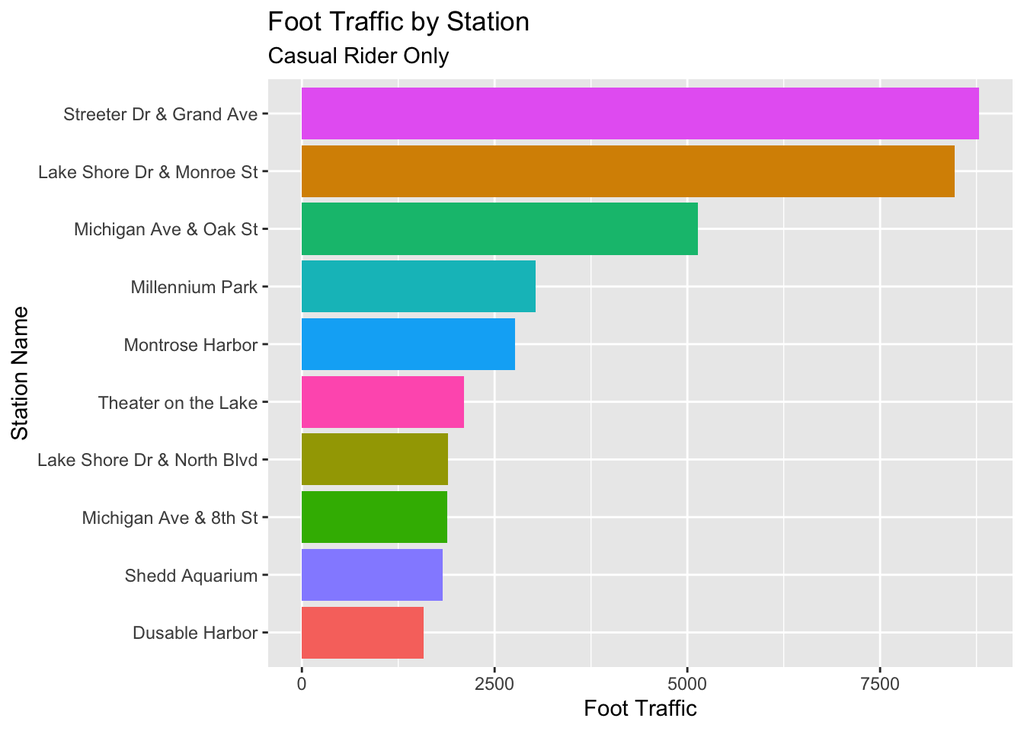

The stations with the highest foot traffic from casual riders are:

1. Streeter Dr. & Grand Ave.
2. Lake Shore Dr. & Monroe St.
3. Michigan Ave. & Oak St.

These stations can be used to target casual riders in the future, so we will keep this in mind.

On average, **member** riders appear to rent Cyclistic bike with regularity, but for a much shorter period of time. Member riders view Cyclist’s bike as essential to their day to day travel. This regular use makes single-use passes very cost inefficient, and in turn, more likely to purchase annual memberships each year.

## What Can Cyclistic Do

At the beginning of this analysis, Cyclistic wanted to understand **how annual members and casual riders use Cyclistic bikes differently**. Through the data collected by the company, we were able to understand how each rider uses Cyclistic bikes.

We found out that annual **members** tend to rent bikes from Cyclistic on weekdays, primarily to be used for travel to and from work. The overwhelming majority of annual members rented their bikes from Monday to Friday for an average of about 15 minutes per rental. These users seem to rely on Cyclistic for their work transpiration needs, rendering single-day passes inefficient and annual memberships valuable to them.

Through the same analysis, we were able to see that **casual** riders typically rent their bikes on the weekends, this time for amusement or a leisure ride. Casual riders rented their bikes on Saturday and Sunday for an average duration of about 55 to 60 minutes. These riders are referred to as casual riders because of their decision to purchase singe-day or single-use passes as opposed to annual memberships.

Cyclistic’s goal is to **increase the number of annual memberships** primarily by **converting casual riders into annual members**, due to their higher profit margins. We now understand a bit more about how annual members and casual riders interact with Cyclistic bikes, and through this analysis, there are a few ways Cyclistic can convert these casual riders:

#### Create an Additional Purchase Option, “Annual Leisure Pass”

The company already knows that a majority of casual riders are aware of Cyclistic’s purchasing options, however they still decide to purchase the single-use or single-day pass. If a casual rider enjoys the service Cyclistic offers, but they do not want to purchase the annual membership, they could benefit from a solid middle ground.

This pass would be in between the price of the single-day pass and the annual membership and would allow any user with the pass to rent out any bikes they like on weekends. It would be considered an annual membership that is active from Friday-Sunday with the same benefits as a standard annual membership.

#### Create Tageted Advertisements at High Foot-Traffic Locations

In our analysis, we were able to find out which stations had the largest amount of foot traffic among casual riders. These Stations can be used to Cyclistic’s benefit. By creating some targeted advertisements in these locations, we can ensure a large number of casual riders view the message. Possible advertisements could include QR codes that offer discount through Cyclistic’s app or a discounted annual membership price for riders at these stations to redeem.

#### Weekday vs. Weekend Pricing

The increased number of casual riders on weekends can provide the company an interesting opportunity. One option Cyclistic can implement is an increased rental cost over the weekends for single-day and single-use passes. This creates a unique opportunity for casual riders to see the increased benefits of the annual membership and, as a result, increase demand for it.

I appreciate you if you got this far. Thank you so much, if you have any suggestions on how to improve any part of the analysis, feel free to shoot me an email!